# Introduction

# Effect of Region on Insurance Charges

```python
#Now, let's see if there is any difference in insurance cost based on region. We will do this by finding the mean and median
    region_charges_mean = insurance.groupby('region').charges.mean()
    region_charges_mean
```

[output not shown]

```python
region_charges_median = insurance.groupby('region').charges.median()
    region_charges_median
```

```
region
    northeast    10057.652025
    northwest     8965.795750
    southeast     9294.131950
    southwest     8798.593000
    Name: charges, dtype: float64
```

# Effect of Sex on Insurance Charges

```python
#Let's see how insurance costs differ for male and females by finding the mean for each gender

    sex_mean = insurance.groupby('sex').charges.mean()
    sex_mean
```

```
sex
    female    12569.578844
    male      13956.751178
    Name: charges, dtype: float64
```

```python
#Let's also look at the median

    sex_median = insurance.groupby('sex').charges.median()
    sex_median
```

```
sex
    female    9412.96250
    male      9369.61575
    Name: charges, dtype: float64
```

Woah, the mean is greater than the median. When this happens, the distribution is right skewed. So, we have outliers in the data. Due to the existence of outliers, We will use the median instead of the mean. So the median insurance charge for females is 9412 and 9369 for males. This means that there isn't much of difference in insurance charge by gender, so gender is not a contributing factor to insurance charges. If we were to plot a boxplot of male and female insurance charges we would see some overlap between the two boxes.

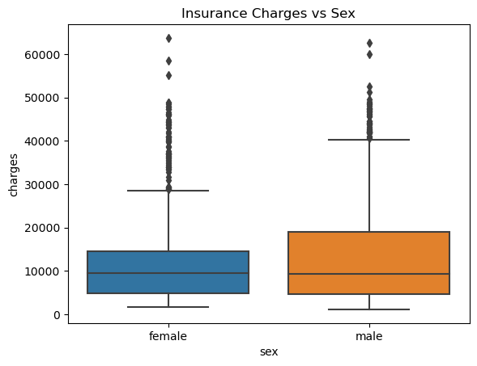

```python
#Let's test and see if there will be overlap in the boxplost between male and female charges
    sns.boxplot(data=insurance, x = 'sex', y='charges')
    plt.title('Insurance Charges vs Sex')
    plt.show()
```

# Effect of Children on Insurance Charges

```python
#Next, we want to know do people with no children pay more than people with atleast 1 child?
    #To do this, we will find the mean and median for insurance charges for the children variable.
    children_mean = insurance.groupby(insurance.children).charges.mean()
    print(children_mean)
```

```
children
    0    12365.975602
    1    12731.171832
    2    15073.563734
    3    15355.318367
    4    13850.656311
    5     8786.035247
    Name: charges, dtype: float64
```

```python
#So, here we a break down of the mean insurance charge for people with 0 to 5 children.
    #Let's have a look at the median.
    children_median = insurance.groupby(insurance.children).charges.median()
    children_median
```

```
children
    0     9856.95190
    1     8483.87015
    2     9264.97915
    3    10600.54830
    4    11033.66170
    5     8589.56505
    Name: charges, dtype: float64
```

So, the we see that the mean is greater than median. When this happens, it is means the distribution is right swkewed. This is means we have some outliers.And because we do have outliers, we are gonna use the median to summarize insurance charges for people with and without children. So, the median charge for people with no children is 9856. With 1 children, the insurance charge is 8483. With 2 children, it is 9264. 3 children, we have 10600. 4 children, we have 11033. Lastly, 5 children, we have 8589.So people with 4 children, pay the most in insurance charges. And 4 children is not the most number of children in our dataset, five is. I would conclude that people with more children do not pay more in insurance charges. Because the median is fairly even across the broad. There isn't any huge difference between each of the five categories.

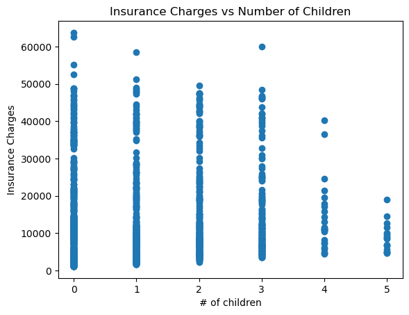

```python
#Let's visualise charges against number of children.
    plt.scatter(insurance.children,insurance.charges)
    plt.title('Insurance Charges vs Number of Children')
    plt.xlabel('# of children')
    plt.ylabel('Insurance Charges')
    plt.show()
```

```python
#Let's calculate the pearson correlation between children and charges
    corr_child_charges,p = scipy.stats.pearsonr(insurance.children, insurance.charges)
    corr_child_charges

    #This result of 0.06 suggets that there is no relationship between the number of children you have and your insurance charges.
```

```
0.06799822684790481
```

# Effect of BMI on Insurance Charges

In order, to see how does BMI affect insurance charges. I am going to group the BMI in 4 categories. According to the CDC website, this is the adult body mass index. If your BMI is less than 18.5, it falls within the underweight range. If your BMI is 18.5 to <25, it falls within the healthy weight range. If your BMI is 25.0 to <30, it falls within the overweight range. If your BMI is 30.0 or higher, it falls within the obesity range.

```python
#So, lets group each person into a category and find the median of their charges.
    underweight = insurance.groupby(insurance.bmi[insurance.bmi < 18.5]).charges.median()
    h_weight = insurance.groupby(insurance.bmi[(insurance['bmi'] >= 18.5) & (insurance['bmi'] < 25.00)]).charges.median()
    overweight = insurance.groupby(insurance.bmi[(insurance['bmi'] >= 25) & (insurance['bmi'] < 30.00)]).charges.median()
    obese = insurance.groupby(insurance.bmi[insurance['bmi'] >= 30.00]).charges.median()


    #Now variables above gives us all the median for all the bmi between the range specificed in the dataset, so we have to go a step further and find the median of that median.
    underweight_median = underweight.median()
    h_weight_median = h_weight.median()
    overweight_median = overweight.median()
    obese_median = obese.median()
    print('The median insurance charge for underweight people is' +  ' ' + str(underweight_median))
    print('The median insurance charge for healthy weight people is' +  ' ' + str(h_weight_median))
    print('The median insurance charge for overweight people is' +  ' ' + str(overweight_median))
    print('The median insurance charge for obese people is' +  ' ' + str(obese_median))

    # pd.set_option('display.max_rows', None)
    #print(h_weight.mean())
```

```
The median insurance charge for underweight people is 5116.5004
    The median insurance charge for healthy weight people is 8605.3615
    The median insurance charge for overweight people is 9253.8685
    The median insurance charge for obese people is 10767.387579999999
```

Based on the above print statements, overweight and obese people pay the most in insurance charges. But obese people pay the most which is 10,767. This was expected because obese people usually have more health problems so this would require a higher insurance charge While obese people pay the most in insurance charges, the difference between the other categories is not highly significant. About 3,400 separate insurance charges for underweight and healthy people and about 1,500 separate charges for overweight people and obese people.

```python
#To really determine the relationship, let's check the pearson's correlation between BMI and insurance charge.
    #Let's see if BMI and insurance charges are correlated by using pearson correlation
    corr_bmi_charges, p_value = scipy.stats.pearsonr(insurance.bmi, insurance.charges)
    corr_bmi_charges
    #The pearson correlation is 0.198. Let's say 0.2
    #I am dissappointed that the correlation is this low. It's close to zero.
    #0.2 tells us that there is a linear association but it is not a strong or high linear association between BMI and charges.
```

```
0.1983409688336289
```

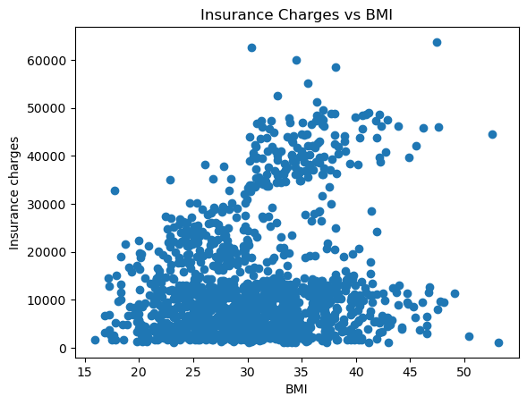

```python
#But this visualize the relationship between BMI and insurance charges
    plt.scatter(insurance.bmi, insurance.charges)
    plt.title('Insurance Charges vs BMI')
    plt.xlabel('BMI')
    plt.ylabel('Insurance charges')
    plt.show()
    #While there is a lot of variation in the plot, there is also a small trend showing people with higher BMI have higher insurance charges.
```

# Effect of Age on Insurance Charges

```python
#Let's find the youngest person in the data set and the oldest person, find the median of insurance charge for that age and then compare them.
    #So first, I''l find the median insurance charge for 18 years old.
    youngestage_median = insurance.groupby(insurance.age[insurance['age'] == 18]).charges.median()
    print(youngestage_median)
    #Next we'll find the median charge for 64 year olds, the oldest age in our dataset
    oldestage_median = insurance.groupby(insurance.age[insurance['age'] == 64]).charges.median()
    print(oldestage_median)
    #Here we see that for the youngest people, the median insurance charge is 2,198.
    #While the oldest people, the median insurance charge is 15,528.
    #We can conclude that older people pay more in insurance which makes sense because they would be more likely prone to illnesses.
```

```
age
    18.0    2198.18985
    Name: charges, dtype: float64
    age
    64.0    15528.758375
    Name: charges, dtype: float64
```

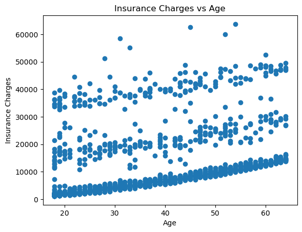

```python
#et's visualize the relationship between insurance charges and age
    plt.scatter(insurance.age,insurance.charges)
    plt.title('Insurance Charges vs Age')
    plt.xlabel('Age')
    plt.ylabel('Insurance Charges')
    plt.show()
```

We see a little upward trend here in this graph. As age increases, so does insurance charges.

```python
#Let's see what is the correlation between age and insurance charges though.
    corr_age_charges, p = scipy.stats.pearsonr(insurance.age, insurance.charges)
    corr_age_charges
    #We have a correlation of 0.3 here. It's not a strong linear association but there is still one as demonstrated
    #by our analysis where we found 64 year olds paying more in insurance cost than 18 year olds on average.
    #The relationship was also demonstrated by our scatter plot where we see the upward trend.
```

```
0.29900819333064765
```

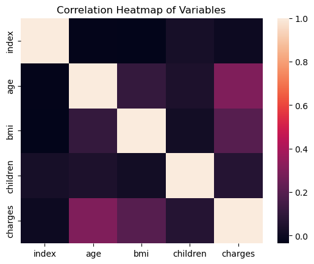

```python
#I will create a heatmap of the correlation between each of our variables to quickly summarize their linear association.
    sns.heatmap(insurance.corr())
    plt.title('Correlation Heatmap of Variables')
```

# FINDINGS:

Based on my analysis, quitting smoking and having a heathly BMI could reduce insurance charges.

# For future consideration:

1. I could analyze how much of the smokers lived in the Northeast and see if this is a contributing to it being the region paying the most in insurance charges.
2. Assess the proportion of those who smoke in the dataset and how many that do not smoke.